# Diabetes EDA & Prediction

## FINAL TUTORIAL : DIABETES EDA & PREDICTION

## Vedant Agrawal UID:118277592

### Motivation of choosing this data and project

Diabetes is a chronic medical condition that affects millions of people worldwide. According to the World Health Organization, the number of people with diabetes has risen from 108 million in 1980 to 422 million in 2014 (Link to reference: https://www.who.int/news-room/fact-sheets/detail/diabetes). The prevalence of diabetes has been increasing rapidly in both developed and developing countries, which makes it a global health concern.

Early diagnosis and effective management of diabetes are crucial to prevent or delay the onset of complications such as cardiovascular disease, blindness, kidney failure, and lower limb amputation. Therefore, accurate prediction of diabetes is of paramount importance for early detection and timely intervention. To learn more about diabetes, the Wikipedia page of diabetes can be refered: https://en.wikipedia.org/wiki/Diabetes

The first step towards building a reliable diabetes prediction model is to perform exploratory data analysis (EDA) on the available dataset. EDA involves examining the characteristics of the data, identifying patterns, trends, and outliers, and understanding the relationships between different variables. EDA is an essential step in any data-driven project as it helps to identify potential issues with the data, select appropriate variables for the analysis, and develop hypotheses for further investigation. Once EDA is complete, the next step is to develop a prediction model that can accurately predict the likelihood of an individual developing diabetes based on their demographic, clinical, and lifestyle characteristics. Machine learning algorithms, such as logistic regression, decision trees, and random forests, can be used to develop the prediction model. These algorithms can learn from the historical data and make predictions on new data based on the learned patterns and relationships. The developed model can be used to identify individuals who are at high risk of developing diabetes, allowing for early intervention and preventive measures. The model can also be used to monitor the progression of the disease and assess the effectiveness of different treatment options.

In addition to the prediction model, the EDA can also provide valuable insights into the underlying causes of diabetes and the factors that contribute to its development. For example, the analysis may reveal that certain demographic groups, such as older adults or individuals with a family history of diabetes, are more likely to develop the disease. It may also identify lifestyle factors, such as physical activity and dietary habits, that are associated with diabetes risk. These insights can inform public health policies and interventions aimed at reducing the incidence of diabetes and improving the overall health of the population.

Hence, I chose Diabetes EDA & Prediction as my final project for the year.

```python
!pip3 install seaborn

# Importing dependencies
import numpy as np
import pandas as pd
import seaborn as sns
import matplotlib.pyplot as plt
from sklearn.preprocessing import LabelEncoder
from sklearn.model_selection import train_test_split
from sklearn.ensemble import RandomForestClassifier
from sklearn.linear_model import LogisticRegression
from sklearn.neighbors import KNeighborsClassifier
from sklearn.tree import DecisionTreeClassifier
from sklearn.metrics import confusion_matrix, accuracy_score
```

### Data Collection

Kaggle is an online community of data scientists and machine learning enthusiasts that hosts a wide variety of datasets and challenges for people to work on. It is a platform where data scientists can share their work, collaborate with others, and compete to create the most accurate models for a given problem. Kaggle provides access to a vast amount of data and resources, including pre-built algorithms and data visualization tools, making it an excellent platform for learning and practicing machine learning. The project used data from the following Kaggle link: https://www.kaggle.com/datasets/iammustafatz/diabetes-prediction-dataset, which is a dataset for predicting the onset of diabetes in patients based on various factors such as bmi, HbA1c level, blood glucose level etc.

```python
diabetes_df = pd.read_csv("diabetes.csv")
```

```python
diabetes_df
```

|  | gender | age | hypertension | heart_disease | smoking_history | bmi | HbA1c_level | blood_glucose_level | diabetes |
| --- | --- | --- | --- | --- | --- | --- | --- | --- | --- |
| 0 | Female | 80.0 | 0 | 1 | never | 25.19 | 6.6 | 140 | 0 |
| 1 | Female | 54.0 | 0 | 0 | No Info | 27.32 | 6.6 | 80 | 0 |
| 2 | Male | 28.0 | 0 | 0 | never | 27.32 | 5.7 | 158 | 0 |
| 3 | Female | 36.0 | 0 | 0 | current | 23.45 | 5.0 | 155 | 0 |
| 4 | Male | 76.0 | 1 | 1 | current | 20.14 | 4.8 | 155 | 0 |
| ... | ... | ... | ... | ... | ... | ... | ... | ... | ... |
| 99995 | Female | 80.0 | 0 | 0 | No Info | 27.32 | 6.2 | 90 | 0 |
| 99996 | Female | 2.0 | 0 | 0 | No Info | 17.37 | 6.5 | 100 | 0 |
| 99997 | Male | 66.0 | 0 | 0 | former | 27.83 | 5.7 | 155 | 0 |
| 99998 | Female | 24.0 | 0 | 0 | never | 35.42 | 4.0 | 100 | 0 |
| 99999 | Female | 57.0 | 0 | 0 | current | 22.43 | 6.6 | 90 | 0 |

100000 rows × 9 columns

### Data Preprocessing

Before starting data cleaning and EDA, it is important to take a look at the data. I used the info() function provided by pandas to get information about the data set such as the number of rows and columns, the features and their data types etc.

```python
diabetes_df.info()
```

```
<class 'pandas.core.frame.DataFrame'>
RangeIndex: 100000 entries, 0 to 99999
Data columns (total 9 columns):
 #   Column               Non-Null Count   Dtype
---  ------               --------------   -----
 0   gender               100000 non-null  object
 1   age                  100000 non-null  float64
 2   hypertension         100000 non-null  int64
 3   heart_disease        100000 non-null  int64
 4   smoking_history      100000 non-null  object
 5   bmi                  100000 non-null  float64
 6   HbA1c_level          100000 non-null  float64
 7   blood_glucose_level  100000 non-null  int64
 8   diabetes             100000 non-null  int64
dtypes: float64(3), int64(4), object(2)
memory usage: 6.9+ MB
```

Since the age has to be a whole number and blood levels can be decimal point numbers I converted the data types of these columns to something more fitting

```python
# Converting d_types of required columns
diabetes_df["age"] = diabetes_df["age"].astype("int64")
diabetes_df["blood_glucose_level"] = diabetes_df["blood_glucose_level"].astype("float64")
```

```python
# Checking for missing values
diabetes_df.isna().sum()
```

```
gender                 0
age                    0
hypertension           0
heart_disease          0
smoking_history        0
bmi                    0
HbA1c_level            0
blood_glucose_level    0
diabetes               0
dtype: int64
```

On checking for missing values, we see that our dataset does not have any missing values. But this is not the entire story. Sometimes some of the non-numerical columns contain data that provide no useful information and we have to take care of them before we perform analysis.

We see that our dataset has two non-numerical features: gender and smoking history. The next step is to look deeper into these two columns

```python
# Counting number of occurences in gender column
diabetes_df["gender"].value_counts()
```

```
Female    58552
Male      41430
Other        18
Name: gender, dtype: int64
```

```python
# Listing the distinct values in smoking history column
diabetes_df.smoking_history.unique()
```

```
array(['never', 'No Info', 'current', 'former', 'ever', 'not current'],
      dtype=object)
```

```python
# Counting number of occurences in smoking history column
diabetes_df["smoking_history"].value_counts()
```

```
No Info        35816
never          35095
former          9352
current         9286
not current     6447
ever            4004
Name: smoking_history, dtype: int64
```

```python
diabetes_df_check = diabetes_df.loc[diabetes_df["smoking_history"] != "No Info"]
diabetes_df_check = diabetes_df_check.loc[diabetes_df["smoking_history"] != "ever"]
diabetes_df_check = diabetes_df_check.loc[diabetes_df["smoking_history"] != "not current"]

#Mapping the categories to number (can be thought of severity of smoking)
smoke_map = {"never" : 0, "former" : 1, "current" : 2}
diabetes_df_check["smoking_history"] = diabetes_df_check["smoking_history"].map(smoke_map)

# Using corr() to make a correlation matrix for the table columns
diabetes_df_check.corr()
```

|  | age | hypertension | heart_disease | smoking_history | bmi | HbA1c_level | blood_glucose_level | diabetes |
| --- | --- | --- | --- | --- | --- | --- | --- | --- |
| age | 1.000000 | 0.259335 | 0.238355 | 0.075920 | 0.171805 | 0.118248 | 0.119250 | 0.268184 |
| hypertension | 0.259335 | 1.000000 | 0.116639 | 0.016860 | 0.131453 | 0.085235 | 0.087357 | 0.193548 |
| heart_disease | 0.238355 | 0.116639 | 1.000000 | 0.054906 | 0.039795 | 0.071466 | 0.077591 | 0.169940 |
| smoking_history | 0.075920 | 0.016860 | 0.054906 | 1.000000 | 0.041632 | 0.012260 | 0.018501 | 0.033077 |
| bmi | 0.171805 | 0.131453 | 0.039795 | 0.041632 | 1.000000 | 0.084908 | 0.096376 | 0.203909 |
| HbA1c_level | 0.118248 | 0.085235 | 0.071466 | 0.012260 | 0.084908 | 1.000000 | 0.194837 | 0.437338 |
| blood_glucose_level | 0.119250 | 0.087357 | 0.077591 | 0.018501 | 0.096376 | 0.194837 | 1.000000 | 0.449457 |
| diabetes | 0.268184 | 0.193548 | 0.169940 | 0.033077 | 0.203909 | 0.437338 | 0.449457 | 1.000000 |

I used a correlation matrix complete the task. A correlation matrix is a table that shows the correlation coefficients between different variables in a dataset. It is a useful tool for identifying the strength and direction of relationships between variables, helping to determine which variables are most strongly related and potentially useful in further analyses. More info can be found on: https://www.displayr.com/what-is-a-correlation-matrix/.

We see that the correlation coefficient of diabetes and smoking history is close to 0 signifying little to none relation between smoking_history and diabetes. Hence I decided to drop the column. Moreover, we had seen that male and female had a lot more data points compared to others when we had explored the gender. Hence, if we limit our analysis to these two genders, we can make more precise inferences.

```python
# Dropping the unecessary data
diabetes_df = diabetes_df.loc[diabetes_df["gender"] != "Other"]
diabetes_df = diabetes_df.drop(columns = "smoking_history")
```

### Exploratory Data Analysis

To perform the exploratory data analysis, my approach was to seperate the feature columns into categorical and continuous. My reasoning for doing so is that it is important to separately plot continuous and categorical variables in data science models because they have different characteristics and require different methods of analysis.

Continuous variables are numeric variables that can take on any value within a certain range. These variables can be measured on a scale. The continuous variables in our dataset include: age, bmi, glucose level and HbA14c levels. I used histograms to plot these features.

On the other hand, categorical variables are non-numeric variables that can take on a limited number of values. These variables cannot be measured on a scale. The categorical variables for the dataset include: gender, hypertension and heart disease. I used countplots to visualize these.

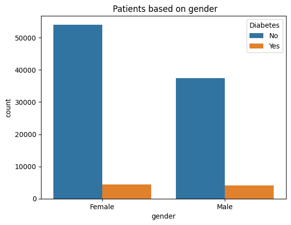

```python
sns.countplot(x = 'gender', hue = 'diabetes' ,data = diabetes_df)
plt.legend(title = "Diabetes" ,labels = ['No', 'Yes'])
plt.title(" Patients based on gender")
plt.show()
```

The countplot for male and female patients was plotted separately to indicate whether they had diabetes or not. By adding the heights of the bars for each gender, we can determine the total number of patients based on gender. Interestingly, the countplot revealed that the number of female patients in the dataset is considerably higher than that of male patients. However, a visual inspection of the plot shows that the number of diabetic patients is relatively similar for both genders. This suggests that the male population has a higher proportion of individuals with diabetes than the female population, despite there being a higher number of female patients in the dataset. We can test this assumption by finding the diabetic percentage for the genders.

```python
# Finding diabetic population based on gender : people with diabetes/ total people for the gender *100
female_percent = len(diabetes_df[(diabetes_df['gender']=='Female') & (diabetes_df['diabetes']== 1)]) / len(diabetes_df[(diabetes_df['gender']=='Female')])*100
male_percent = len(diabetes_df[(diabetes_df['gender']=='Male') & (diabetes_df['diabetes']== 1)]) / len(diabetes_df[(diabetes_df['gender']=='Male')])*100
print("Female diabetes percent: " + str(round(female_percent,2)))
print("Male diabetes percent: " + str(round(male_percent,2)))
```

```
Female diabetes percent: 7.62
Male diabetes percent: 9.75
```

I turns out that our assumption was correct.

Now we plot the other two categorical variables using similar approach of count plots

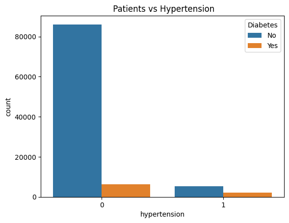

```python
sns.countplot(x = 'hypertension', hue = 'diabetes' ,data = diabetes_df)
plt.legend(title = "Diabetes" ,labels = ['No', 'Yes'])
plt.title(" Patients vs Hypertension")
plt.show()
```

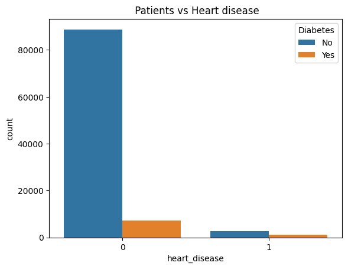

```python
sns.countplot(x = 'heart_disease', hue = 'diabetes' ,data = diabetes_df)
plt.legend(title = "Diabetes" ,labels = ['No', 'Yes'])
plt.title(" Patients vs Heart disease")
plt.show()
```

It is clear that the majority of our dataset is patients without hypertension and any kind of heart disease. Since the data is biased towards one type of value, it is hard to say that having any of these conditions significantly affects if the patient has diabetes or not.

```python
# Making a list with our continuous variable col names
continuous = ['age', 'bmi','HbA1c_level','blood_glucose_level']
```

In this project, histograms were used to analyze the distribution of continuous variables in the dataset.

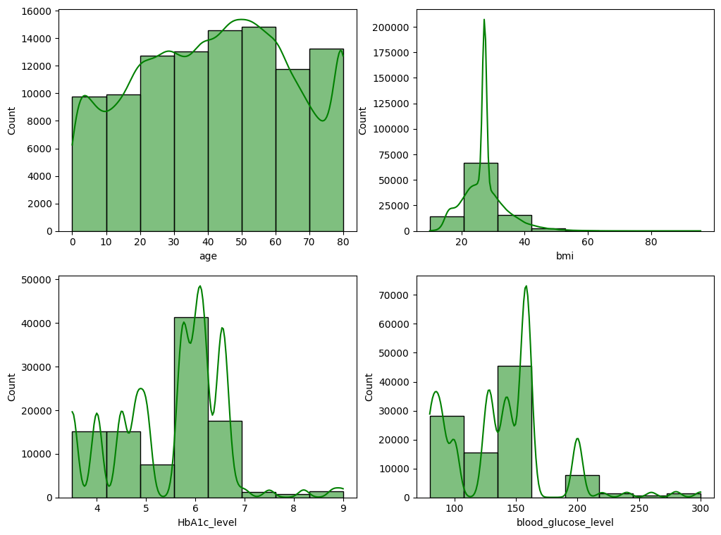

```python
# plotting all the continuous variables using subplots
fig, axes = plt.subplots(nrows = 2, ncols = 2, figsize = (12, 9))
for i, ax in enumerate(axes.flatten()):
    sns.histplot(diabetes_df[continuous[i]], bins = 8, kde = True, ax = ax, color = "green")
plt.show()
```

After analysing the trends in the dataset I used research (https://diabetesjournals.org/care/article/35/12/2650/38582/Diabetes-in-Older-Adults) and common sense to put forward an assumption that age increases the risk of diabetes. To check if this assumption was correct I use violin plot to plot diabetic and non-diabetic patients basedd on age.

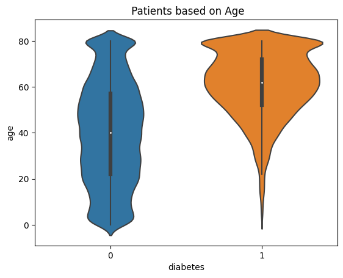

```python
# plotting age vs patients violin plot
sns.violinplot(data=diabetes_df, x="diabetes", y="age")
plt.title(" Patients based on Age")
plt.show()
```

Our assumption was correct and we see that the plot of patients with diabetes is highly skewed towards older patients. Therefore, aging increases the risk of diabetes. But why? To answer that I looked into other features to find the dependency of diabetes on them. I used a heat map.

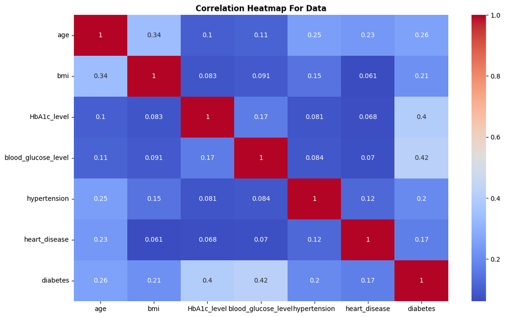

```python
# Adding the categorical variables to the list of variables to make a heat map
continuous.extend(['hypertension', 'heart_disease', 'diabetes'])

#Making the heat map to find correlations
plt.figure(figsize = (13,8))
sns.heatmap(diabetes_df[continuous].corr(), annot = True, cmap = 'coolwarm')
plt.title("Correlation Heatmap For Data", fontweight='bold')
plt.show()
```

Looking at the heat map, we see that the correlation efficients for diabetes-HbA1c and diabetes-blood_glucose are significantly positive. THis signifies that there is a high positive correlation between these variables. To confirm these observations, I made scatter plots to categorically place the HbA1c_levels and glucose_levels that signify diabetes.

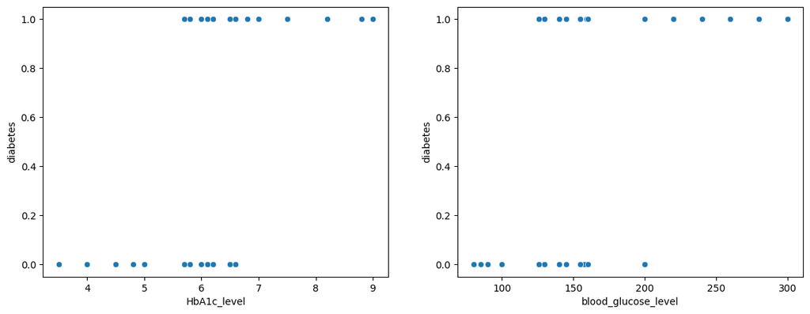

```python
# Setting the figure size
fig = plt.figure(figsize = (14, 5))

# Making the subplot
ax = plt.subplot(1,2,1)

plt.subplot(1,2,1)
sns.scatterplot(x ='HbA1c_level', y= 'diabetes', data= diabetes_df)

plt.subplot(1,2,2)
sns.scatterplot(x ='blood_glucose_level', y= 'diabetes', data= diabetes_df)
```

Turns out that our observations were correct. Higher HbA1c_level and glucose_levels does in fact result in diabetes. So if we could find a reltaion between age and and these two features, maybe we will have the answer to the question we asked before. In order to do so, I made lineplots of Hb1Ac levels vs age and blood glucose levels vs age. Moreover, I divided the lineplot into males and females so it will also give us an idea of how differently age affects blood sugar levels in males and females

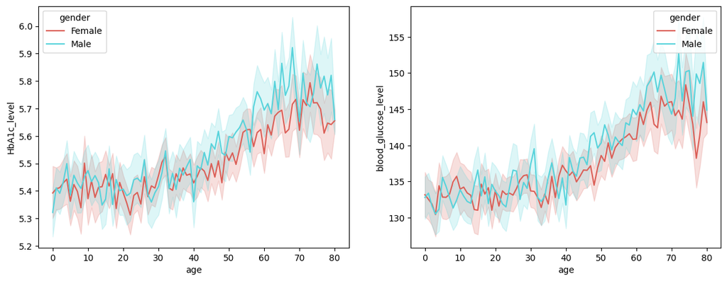

```python
# Setting the figure size
fig = plt.figure(figsize = (14, 5))

# Making the subplot
ax = plt.subplot(1,2,1)

plt.subplot(1,2,1)
sns.lineplot(x = 'age', y ='HbA1c_level', hue = 'gender', data = diabetes_df, palette = 'hls')

plt.subplot(1,2,2)
sns.lineplot(x = 'age', y ='blood_glucose_level', hue = 'gender', data = diabetes_df, palette = 'hls')
```

The plots confirm that aging results in higher levels of Hb1Ac and glucose in the blood. This answers the question that since these levels significantly increase as we age, the risk of getting diabetes also increases with age. As for the differences based on gender, the graph suggests that when we are young, males and females have similar Hb!Ac and blood glucose levels but as we grow older, males experience a higher increase in these levels which is also the reason that a higher proportion of male population has diabetes as compared to the female population.

### Machine Learning and Prediction

Now that we are done with analysis, it is time to fit a model to the dataset and start predicting!!!! But first we need to change the male and female labels to something numeric that the model understands. For this purpose, I used the label encoder. To find more about label encoding refer: https://www.geeksforgeeks.org/ml-label-encoding-of-datasets-in-python/

```python
# Using label encoder to change categorical labels to numerical
l_encoder = LabelEncoder()
diabetes_df['gender'] = l_encoder.fit_transform(diabetes_df['gender'])
```

Next we split our dataset into training and testing dataset. While we do this we also split our features (X) from our target (y). As to why I chose 42 as the random_state, https://grsahagian.medium.com/what-is-random-state-42-d803402ee76b has the answer to that. ("It is much more mundane than you would think")

```python
# train-test splitting
X = diabetes_df.drop(columns=['diabetes'])
y = diabetes_df['diabetes']
X_train, X_test, y_train, y_test = train_test_split(X, y, test_size=0.2, random_state=42)
```

Next, I used the RFC to see the importance of each feature in predicting the target. As we would expect, HbA1c_level and blood_glucose_level are the most important features for our model.

```python
# Fitting RandomForest to list feature importance
rfc = RandomForestClassifier(n_estimators=100, random_state=42)
rfc.fit(X_train, y_train)
feat_importances = rfc.feature_importances_
for feature, importance in zip(X.columns, feat_importances):
    print(f'{feature}: {round(importance,2)}')
```

```
gender: 0.01
age: 0.1
hypertension: 0.01
heart_disease: 0.01
bmi: 0.14
HbA1c_level: 0.41
blood_glucose_level: 0.32
```

Now, it is time to start fitting and testing various classification models to find which one is the best model for us. Since we have already fit RFC to the train dataset, we can test it by using predict() and predictng the target values for the testing dataset. To read more about RFC : https://www.datacamp.com/tutorial/random-forests-classifier-python

```python
# Testing RandomForestClassifier
y_pred = rfc.predict(X_test)
print("Accuracy: " + str(accuracy_score(y_test, y_pred)))
```

```
Accuracy: 0.9688953343001451
```

The next model I fit and tested was LogisticRegression. To learn more about it:https://www.datacamp.com/tutorial/understanding-logistic-regression-python

```python
# Fitting and Testing Logstic Regression
lr = LogisticRegression(random_state =42)
lr.fit(X_train,y_train)
y_pred = lr.predict(X_test)
print("Accuracy: " + str(accuracy_score(y_test, y_pred)))
```

```
Accuracy: 0.9576936540481072
```

The next model I fit and tested was KNeighborsClassifier. To learn more about it:https://www.datacamp.com/tutorial/k-nearest-neighbor-classification-scikit-learn

```python
# Fitting and Testing KNeighborsClassifier
knc = KNeighborsClassifier(n_neighbors = 6)
knc.fit(X_train, y_train)
y_pred = knc.predict(X_test)
print("Accuracy: " + str(accuracy_score(y_test, y_pred)))
```

```
Accuracy: 0.9546932039805971
```

The next model I fit and tested was DecisionTreeClassifier. To learn more about it:https://www.datacamp.com/tutorial/decision-tree-classification-python

```python
# Fitting and Testing DecisionTreeClassifier
dtc = DecisionTreeClassifier()
dtc.fit(X_train, y_train)
y_pred = dtc.predict(X_test)
print("Accuracy: " + str(accuracy_score(y_test, y_pred)))
```

```
Accuracy: 0.9524428664299645
```

Now that we have tried enough models, it is time to find the best one. TO do that I simply listed the accuracy score of the predictions made by every model and compared them.

```python
# Listing out the accuracies
accuracy_df = pd.DataFrame({'Model':['Logistic Regression', 'K Neighbors Classifier', 'Decision Tree Classifier', 'Random Forest Classifier'],
                           'Accuracy':[95.76,95.46,95.22,96.88]})
accuracy_df
```

[output not shown]

The Winner is RandomForestClassifier with an accuracy of 96.88 !!!!! This does not necessarily mean that it is the best algortihm out of all the models we used. It just means it worked the best for the particular dataset and will work good enough for completely new datasets.

### Conclusion

In summary, this project aimed to analyze a diabetes dataset to gain insights into the distribution of key variables and explore the relationships between them. The countplot analysis revealed that there were more female patients in the dataset than male patients. However, despite this, the male population had a higher proportion of individuals with diabetes than the female population. Further analysis showed that age was a significant factor in diabetes risk, with aging increasing the risk of diabetes. This conclusion was supported by violin plots, which showed that patients with diabetes were skewed towards older patients. A heatmap and scatter plots were used to explore the relationships between diabetes and other variables. The results indicated that HbA1c levels and blood glucose levels were significantly positively correlated with diabetes, and higher levels of HbA1c and blood glucose increased the risk of diabetes. Line plots were also used to investigate the relationship between age and these variables, which showed that as age increased, so did HbA1c and blood glucose levels, explaining the increased diabetes risk with age. Moreover, the line plots suggested that males experienced a higher increase in HbA1c and blood glucose levels as they grew older, which could explain the higher proportion of male patients with diabetes compared to females. The project was finally concluded by making a machine learning model that can predict diabetes with an accuracy 96.88% . Overall, the project provided valuable insights into the distribution of key variables in the diabetes dataset and highlighted the relationships between them, specifically between age, HbA1c levels, blood glucose levels, and diabetes risk. These findings could inform further analyses and model building and potentially lead to better prevention and management strategies for diabetes.